# Comparison of bias correction methods for TRMM calibration with respect to extreme precipitation events over Iberian Peninsula during 1998-2010

Óscar Mirones Alonso

Abstract

In this notebook, several standard bias correction methods are made. Four main methods are computed with the biasCorrection function (scale, eqm, pqm and gpqm). Then, the index computed with observational data, TRMM non-calibrated data and TRMM-calibrated are compared.Observation/TRMM/Corrected density functions are compared on the same graph to see the effect of the correction. Also these data are shown in QQplots. The goal is to check the improvement in the index calculation after the bias correction. This methodology is done in four different stations among the Iberian Peninsula (Madrid-Barajas, Málaga, Palma de Mallorca, San Sebastián-Igueldo). (Navacerrada and Santiago de Compostela stations have been added.)

```r
library(loadeR)
library(transformeR)
library(downscaleR)
library(visualizeR)
library(climate4R.value)
library(evd)
library(formattable) #neccessary to create tables with colors
library(lubridate) #neccessary to calculate differences in years between dates
```

Load the VALUE package to obtain observational data

```r
library(VALUE)

value.dataset <- file.path(find.package("VALUE"), "example_datasets", "VALUE_ECA_86_v2.zip")

obs <- loadStationData(dataset = value.dataset, var = "precip", tz = "GMT",
                              lonLim = c(-10,4.5),
                              latLim = c(34.7,44),
                                )
```

Year subsetting of observational data.

```
pad applied on the interval: day
```

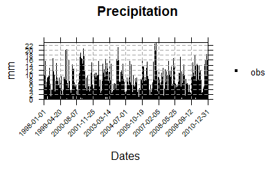

```r
obs <- subsetGrid(obs, years = 1998:2010)
temporalPlot(obs, xyplot.custom = list(main = "Precipitation", ylab = "mm"))
```

Loading the .ncml file corresponding to TRMM daily data.

```r
setwd("C:/Users/usuario/Desktop/TRMM_3B42_Daily_V7")
```

```
The working directory was changed to C:/Users/usuario/Desktop/TRMM_3B42_Daily_V7 inside a notebook chunk. The working directory will be reset when the chunk is finished running. Use the knitr root.dir option in the setup chunk to change the working directory for notebook chunks.
```

```r
inventory <- dataInventory("inventory.ncml")
```

```
[2021-01-19 12:34:56] Doing inventory ...
[2021-01-19 12:34:58] Retrieving info for 'precipitation_cnt' (7 vars remaining)
[2021-01-19 12:34:58] Retrieving info for 'IRprecipitation' (6 vars remaining)
[2021-01-19 12:34:58] Retrieving info for 'IRprecipitation_cnt' (5 vars remaining)
[2021-01-19 12:34:58] Retrieving info for 'HQprecipitation' (4 vars remaining)
[2021-01-19 12:34:58] Retrieving info for 'HQprecipitation_cnt' (3 vars remaining)
[2021-01-19 12:34:58] Retrieving info for 'randomError' (2 vars remaining)
[2021-01-19 12:34:58] Retrieving info for 'randomError_cnt' (1 vars remaining)
[2021-01-19 12:34:58] Retrieving info for 'precipitation' (0 vars remaining)
[2021-01-19 12:34:58] Done.
```

TRMM year,longitude and latitude subsetting.

```r
trmm <- loadGridData(dataset = "C:/Users/usuario/Desktop/TRMM_3B42_Daily_V7/inventory.ncml",
             var = "precipitation",
             lonLim = c(-10,4.5),
             latLim = c(34.7,44) ,
             years = 1998:2010)
```

```
[2021-01-19 12:35:05] Defining geo-location parameters
[2021-01-19 12:35:05] Defining time selection parameters
[2021-01-19 12:35:05] Retrieving data subset ...
[2021-01-19 12:35:37] Done
```

```
pad applied on the interval: day
```

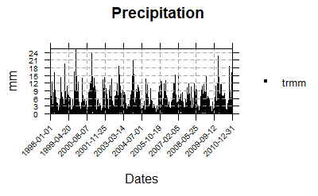

```r
temporalPlot(trmm, xyplot.custom = list(main = "Precipitation", ylab = "mm"))
```

Comparision of both time series

```
pad applied on the interval: day
pad applied on the interval: day
```

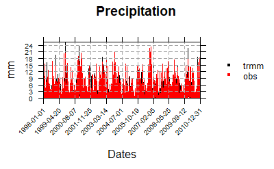

```r
temporalPlot(trmm,obs, xyplot.custom = list(main = "Precipitation", ylab = "mm"))
```

```r
MaxReturnValue <- function(data){
  #library(lubridate)
  #nyears <- round(time_length(difftime(cal.madrid.eqm$Dates$end[length(cal.madrid.eqm$Dates$end)], cal.madrid.eqm$Dates$start[1]),"years"))
  nyears <- 20
  data.maxYear <- aggregateGrid(redim(data), aggr.y = list(FUN = "max",na.rm = TRUE))

  data.maxrv <- climatology(data, clim.fun = list(FUN = "mean", na.rm = T))

  auxData <- data.maxYear$Data
  auxData[which(is.infinite(auxData))] <- NA

  if (any(!is.na(auxData))){
      auxGEV <- fgev(auxData)
      if ((auxGEV$estimate[3] - auxGEV$std.err[3] < 0) & (0  < auxGEV$estimate[3] + auxGEV$std.err[3])){
        auxGEV <- fgev(auxData, shape = 0)
        auxRV <- qgev(1-1/nyears, loc = auxGEV$estimate[1], scale = auxGEV$estimate[2], shape = 0)
      }else{
        auxRV <- qgev(1-1/nyears, loc = auxGEV$estimate[1], scale = auxGEV$estimate[2], shape = auxGEV$estimate[3])
      }
      data.maxrv <- as.numeric(auxRV)
      names(data.maxrv) <- paste("RV",nyears,"_max", sep = "")
  }
  return(data.maxrv)
  }
```

Now, for each of the four stations mentioned above, several extreme precipitation event index are computed and compared, looking for what method best approximates them.

# MADRID-BARAJAS

```r
obs.madrid <- subsetGrid(obs, station.id = obs$Metadata$station_id[11])
idx <- which.min(abs(trmm$xyCoords$x - obs.madrid$xyCoords$x))

lon <- trmm$xyCoords$x[idx]

idx2 <- which.min(abs(trmm$xyCoords$y - obs.madrid$xyCoords$y))
lat <- trmm$xyCoords$y[idx2]

trmm.madrid <- subsetGrid(trmm, lonLim = lon, latLim = lat)
```

First, index corresponding to observational and TRMM are calculated below.

```r
index.obs.madrid <- valueIndex1D(obs.madrid$Data,index.codes=c("Skewness","R10","R10p","R20","R20p","P98Wet","P98WetAmount"))
index.obs.madrid.rv13max <- MaxReturnValue(obs.madrid)
index.trmm.madrid <- valueIndex1D(trmm.madrid$Data,index.codes=c("Skewness","R10","R10p","R20","R20p","P98Wet","P98WetAmount"))
index.trmm.madrid.rv13max <- MaxReturnValue(trmm.madrid)
```

A scaling bias correction is made with leave one year out as crossvalidation. Once made this correction, the calibrated TRMM index are computed.

```r
cal.madrid.scaling <- biasCorrection(y = obs.madrid, x = trmm.madrid, newdata = trmm.madrid, precipitation = TRUE, cross.val = "loo", method = "scaling", scaling.type = "multiplicative")

cal.madrid.scaling$Dates$start <- as.POSIXct(cal.madrid.scaling$Dates$start,tz = "GMT")
cal.madrid.scaling$Dates$end <- as.POSIXct(cal.madrid.scaling$Dates$end,tz = "GMT")


index.cal.madrid.scaling <- valueIndex1D(cal.madrid.scaling$Data,index.codes=c("Skewness","R10","R10p","R20","R20p","P98Wet","P98WetAmount"))


index.cal.madrid.scaling.rv13max <- MaxReturnValue(cal.madrid.scaling)
```

This step is analogue to previous one, in this case the bias correction method is EQM.

```r
cal.madrid.eqm <- biasCorrection(y = obs.madrid, x = trmm.madrid, newdata = trmm.madrid, precipitation = TRUE, cross.val = "loo", method = "eqm")

cal.madrid.eqm$Dates$start <- as.POSIXct(cal.madrid.eqm$Dates$start,tz = "GMT")
cal.madrid.eqm$Dates$end <- as.POSIXct(cal.madrid.eqm$Dates$end,tz = "GMT")
```

Index are computed from the EQM-calibrated TRMM data.

```r
index.cal.madrid.eqm <- valueIndex1D(cal.madrid.eqm$Data,index.codes=c("Skewness","R10","R10p","R20","R20p","P98Wet","P98WetAmount"))

index.cal.madrid.eqm.rv13max <- MaxReturnValue(cal.madrid.eqm)
```

```r
cal.madrid.eqm.extrapol <- biasCorrection(y = obs.madrid, x = trmm.madrid, newdata = trmm.madrid, precipitation = TRUE, cross.val = "loo", method = "eqm", extrapolation = "constant")

cal.madrid.eqm.extrapol$Dates$start <- as.POSIXct(cal.madrid.eqm.extrapol$Dates$start,tz = "GMT")
cal.madrid.eqm.extrapol$Dates$end <- as.POSIXct(cal.madrid.eqm.extrapol$Dates$end,tz = "GMT")
```

```r
index.cal.madrid.eqm.extrapol <- valueIndex1D(cal.madrid.eqm.extrapol$Data,index.codes=c("Skewness","R10","R10p","R20","R20p","P98Wet","P98WetAmount"))

index.cal.madrid.eqm.extrapol.rv13max <- MaxReturnValue(cal.madrid.eqm.extrapol)
```

```
[2021-02-08 12:52:51] Performing annual aggregation...
[2021-02-08 12:52:51] Done.
[2021-02-08 12:52:51] - Computing climatology...
[2021-02-08 12:52:51] - Done.
```

Finally, these steps are repeated using PQM and GPQM as calibration methods.

```r
cal.madrid.pqm <- biasCorrection(y = obs.madrid, x = trmm.madrid, newdata = trmm.madrid, precipitation = TRUE, cross.val = "loo", method = "pqm",  fitdistr.args = list(densfun = "gamma"))

cal.madrid.pqm$Dates$start <- as.POSIXct(cal.madrid.pqm$Dates$start,tz = "GMT")
cal.madrid.pqm$Dates$end <- as.POSIXct(cal.madrid.pqm$Dates$end,tz = "GMT")

index.cal.madrid.pqm <- valueIndex1D(cal.madrid.pqm$Data,index.codes=c("Skewness","R10","R10p","R20","R20p","P98Wet","P98WetAmount"))

index.cal.madrid.pqm.rv13max <- MaxReturnValue(cal.madrid.pqm)
```

```r
cal.madrid.gpqm <- biasCorrection(y = obs.madrid, x = trmm.madrid, newdata = trmm.madrid, precipitation = TRUE, cross.val = "loo", method = "gpqm",  theta = .70)
```

[output not shown]

```r
cal.madrid.gpqm$Dates$start <- as.POSIXct(cal.madrid.gpqm$Dates$start,tz = "GMT")
cal.madrid.gpqm$Dates$end <- as.POSIXct(cal.madrid.gpqm$Dates$end,tz = "GMT")

index.cal.madrid.gpqm <- valueIndex1D(cal.madrid.gpqm$Data,index.codes=c("Skewness","R10","R10p","R20","R20p","P98Wet","P98WetAmount"))

index.cal.madrid.gpqm.rv13max <- MaxReturnValue(cal.madrid.gpqm)
```

The results is shown in dataframe format to compare which correction is closer to the observational data.

```r
index.obs.madrid <- c(index.obs.madrid,index.obs.madrid.rv13max)
index.trmm.madrid <- c(index.trmm.madrid,index.trmm.madrid.rv13max)
index.cal.madrid.scaling <- c(index.cal.madrid.scaling,index.cal.madrid.scaling.rv13max)
index.cal.madrid.eqm <- c(index.cal.madrid.eqm,index.cal.madrid.eqm.rv13max)
index.cal.madrid.eqm.extrapol <- c(index.cal.madrid.eqm.extrapol,index.cal.madrid.eqm.extrapol.rv13max)
index.cal.madrid.pqm <- c(index.cal.madrid.pqm,index.cal.madrid.pqm.rv13max)
index.cal.madrid.gpqm <- c(index.cal.madrid.gpqm,index.cal.madrid.gpqm.rv13max)


results.madrid <- data.frame(index.obs.madrid, index.trmm.madrid, index.cal.madrid.scaling,
                      index.cal.madrid.eqm,index.cal.madrid.eqm.extrapol, index.cal.madrid.pqm, index.cal.madrid.gpqm
                      )
colnames(results.madrid) <- c("Obs","TRMM","Scaling_cal", "EQM_cal","EQM_cal.Extrapol", "PQM_cal","GPQM_cal")

format(results.madrid, digits = 3, scientific = 5)
```

|  | Obs | TRMM | Scaling_cal | EQM_cal | EQM_cal.Extrapol | PQM_cal | GPQM_cal |
| --- | --- | --- | --- | --- | --- | --- | --- |
| Skewness | 5.59133 | 6.0557 | 6.06006 | 5.61442 | 6.11859 | 5.68971 | 5.94292 |
| R10 | 0.03307 | 0.0415 | 0.02906 | 0.03391 | 0.03391 | 0.03117 | 0.02275 |
| R10p | 2588.90000 | 3981.9188 | 2536.27904 | 2669.56085 | 2683.36266 | 2622.24160 | 1913.53219 |
| R20 | 0.00716 | 0.0173 | 0.00885 | 0.00737 | 0.00737 | 0.00906 | 0.00527 |
| R20p | 918.40000 | 2425.8807 | 1164.12287 | 959.12401 | 972.92583 | 1158.77419 | 703.00149 |
| P98Wet | 26.24800 | 36.7235 | 29.22314 | 26.89878 | 26.89878 | 28.45935 | 25.63165 |
| P98WetAmount | 493.60000 | 782.7118 | 543.79796 | 506.80793 | 520.60974 | 527.98023 | 481.35338 |
| RV20_max | 43.62938 | 69.5616 | 53.36134 | 50.98728 | 63.86404 | 51.38545 | 48.15267 |

```r
results.madrid
```

|  | Obs | TRMM | Scaling_cal | EQM_cal | EQM_cal.Extrapol | PQM_cal | GPQM_cal |
| --- | --- | --- | --- | --- | --- | --- | --- |
| Skewness | 5.591333e+00 | 6.055695e+00 | 6.060057e+00 | 5.614418e+00 | 6.118588e+00 | 5.689714e+00 | 5.942918e+00 |
| R10 | 3.306655e-02 | 4.149115e-02 | 2.906487e-02 | 3.390901e-02 | 3.390901e-02 | 3.117102e-02 | 2.274642e-02 |
| R10p | 2.588900e+03 | 3.981919e+03 | 2.536279e+03 | 2.669561e+03 | 2.683363e+03 | 2.622242e+03 | 1.913532e+03 |
| R20 | 7.160910e-03 | 1.727043e-02 | 8.845830e-03 | 7.371525e-03 | 7.371525e-03 | 9.056445e-03 | 5.265375e-03 |
| R20p | 9.184000e+02 | 2.425881e+03 | 1.164123e+03 | 9.591240e+02 | 9.729258e+02 | 1.158774e+03 | 7.030015e+02 |
| P98Wet | 2.624800e+01 | 3.672349e+01 | 2.922314e+01 | 2.689878e+01 | 2.689878e+01 | 2.845935e+01 | 2.563165e+01 |
| P98WetAmount | 4.936000e+02 | 7.827118e+02 | 5.437980e+02 | 5.068079e+02 | 5.206097e+02 | 5.279802e+02 | 4.813534e+02 |
| RV20_max | 4.362938e+01 | 6.956158e+01 | 5.336134e+01 | 5.098728e+01 | 6.386404e+01 | 5.138545e+01 | 4.815267e+01 |

Also, the difference in absolute value between observational data and calibration data is presented in another dataframe. TRMM differences are also included.

```r
 diff.madrid <- data.frame(abs(index.trmm.madrid-index.obs.madrid),abs(index.cal.madrid.scaling-index.obs.madrid),
                      abs(index.cal.madrid.eqm-index.obs.madrid), abs(index.cal.madrid.eqm.extrapol-index.obs.madrid), abs(index.cal.madrid.pqm-index.obs.madrid), abs(index.cal.madrid.gpqm-index.obs.madrid)
                      )
colnames(diff.madrid) <- c("TRMM","Scaling_cal", "EQM_cal","EQM_cal.Extrapol", "PQM_cal.","GPQM_cal")

format(diff.madrid, digits = 3, scientific = 5)
```

|  | TRMM | Scaling_cal | EQM_cal | EQM_cal.Extrapol | PQM_cal. | GPQM_cal |
| --- | --- | --- | --- | --- | --- | --- |
| Skewness | 0.46436 | 0.46872 | 0.023085 | 0.527255 | 0.0984 | 0.3516 |
| R10 | 0.00842 | 0.00400 | 0.000842 | 0.000842 | 0.0019 | 0.0103 |
| R10p | 1393.01879 | 52.62096 | 80.660845 | 94.462662 | 33.3416 | 675.3678 |
| R20 | 0.01011 | 0.00168 | 0.000211 | 0.000211 | 0.0019 | 0.0019 |
| R20p | 1507.48071 | 245.72287 | 40.724012 | 54.525829 | 240.3742 | 215.3985 |
| P98Wet | 10.47549 | 2.97514 | 0.650782 | 0.650782 | 2.2113 | 0.6164 |
| P98WetAmount | 289.11184 | 50.19796 | 13.207926 | 27.009742 | 34.3802 | 12.2466 |
| RV20_max | 25.93220 | 9.73196 | 7.357893 | 20.234656 | 7.7561 | 4.5233 |

```r
diff.madrid
```

|  | TRMM | Scaling_cal | EQM_cal | EQM_cal.Extrapol | PQM_cal. | GPQM_cal |
| --- | --- | --- | --- | --- | --- | --- |
| Skewness | 4.643620e-01 | 4.687238e-01 | 0.023084900 | 0.527254763 | 9.838106e-02 | 3.515854e-01 |
| R10 | 8.424600e-03 | 4.001685e-03 | 0.000842460 | 0.000842460 | 1.895535e-03 | 1.032013e-02 |
| R10p | 1.393019e+03 | 5.262096e+01 | 80.660845416 | 94.462662067 | 3.334160e+01 | 6.753678e+02 |
| R20 | 1.010952e-02 | 1.684920e-03 | 0.000210615 | 0.000210615 | 1.895535e-03 | 1.895535e-03 |
| R20p | 1.507481e+03 | 2.457229e+02 | 40.724012256 | 54.525828907 | 2.403742e+02 | 2.153985e+02 |
| P98Wet | 1.047549e+01 | 2.975143e+00 | 0.650782213 | 0.650782213 | 2.211350e+00 | 6.163529e-01 |
| P98WetAmount | 2.891118e+02 | 5.019796e+01 | 13.207925734 | 27.009742385 | 3.438023e+01 | 1.224662e+01 |
| RV20_max | 2.593220e+01 | 9.731958e+00 | 7.357892870 | 20.234656396 | 7.756068e+00 | 4.523290e+00 |

If we want to know, where the observations are overestimated or underestimated, with the next table we can clearly check it. Blue designates underestimation, while red designates overestimation.

```r
 diff.madrid.noabs <- data.frame(index.trmm.madrid-index.obs.madrid,index.cal.madrid.scaling-index.obs.madrid,
                      index.cal.madrid.eqm-index.obs.madrid, index.cal.madrid.eqm.extrapol-index.obs.madrid, index.cal.madrid.pqm-index.obs.madrid, index.cal.madrid.gpqm-index.obs.madrid)
colnames(diff.madrid.noabs) <- c("TRMM","Scaling_cal", "EQM_cal","EQM_cal.Extrapol", "PQM_cal","GPQM_cal")

#options("scipen"=100, "digits"=4)

formattable(diff.madrid.noabs, list(
  'TRMM' = formatter("span",
                         style = ~style(font.weight = "bold", color =
                                          ifelse(TRMM > 0,"red",
                                                 ifelse(TRMM == 0,"black",
                                                        ifelse(TRMM <0, "blue",NA))))),
  'Scaling_cal' = formatter("span",
                          style = ~style(font.weight = "bold", color =
                                           ifelse(Scaling_cal > 0,"red",
                                                  ifelse(Scaling_cal == 0,"black",
                                                         ifelse(Scaling_cal <0, "blue",NA))))),

   'EQM_cal' = formatter("span",
                          style = ~style(font.weight = "bold", color =
                                           ifelse(EQM_cal > 0,"red",
                                                  ifelse(EQM_cal == 0,"black",
                                                         ifelse(EQM_cal <0, "blue",NA))))),
   'EQM_cal.Extrapol' = formatter("span",
                         style = ~style(font.weight = "bold", color =
                                           ifelse(EQM_cal.Extrapol > 0,"red",
                                                  ifelse(EQM_cal.Extrapol == 0,"black",
                                                         ifelse(EQM_cal.Extrapol <0, "blue",NA))))),
   'PQM_cal' = formatter("span",
                          style = ~style(font.weight = "bold", color =
                                           ifelse(PQM_cal > 0,"red",
                                                  ifelse(PQM_cal == 0,"black",
                                                         ifelse(PQM_cal <0, "blue",NA))))),
   'GPQM_cal' = formatter("span",
                          style = ~style(font.weight = "bold", color =
                                           ifelse(GPQM_cal > 0,"red",
                                                  ifelse(GPQM_cal == 0,"black",
                                                         ifelse(GPQM_cal <0, "blue",NA)))))
 ))
```

|  | TRMM | Scaling_cal | EQM_cal | EQM_cal.Extrapol | PQM_cal | GPQM_cal |
| --- | --- | --- | --- | --- | --- | --- |
| Skewness | 4.643620e-01 | 0.468723778 | 0.023084900 | 0.527254763 | 0.098381064 | 3.515854e-01 |
| R10 | 8.424600e-03 | -0.004001685 | 0.000842460 | 0.000842460 | -0.001895535 | -1.032013e-02 |
| R10p | 1.393019e+03 | -52.620958480 | 80.660845416 | 94.462662067 | 33.341596869 | -6.753678e+02 |
| R20 | 1.010952e-02 | 0.001684920 | 0.000210615 | 0.000210615 | 0.001895535 | -1.895535e-03 |
| R20p | 1.507481e+03 | 245.722873532 | 40.724012256 | 54.525828907 | 240.374185501 | -2.153985e+02 |
| P98Wet | 1.047549e+01 | 2.975143155 | 0.650782213 | 0.650782213 | 2.211349652 | -6.163529e-01 |
| P98WetAmount | 2.891118e+02 | 50.197959804 | 13.207925734 | 27.009742385 | 34.380231302 | -1.224662e+01 |
| RV20_max | 2.593220e+01 | 9.731958478 | 7.357892870 | 20.234656396 | 7.756067704 | 4.523290e+00 |

```r
NA
NA
```

Finally, the density functions and QQPlots for observational data, TRMM and each correction method is computed. This comparison can help visually to check the effect of the correction of the satellite data.

```r
plot(density(obs.madrid$Data, na.rm = TRUE),
main = "Obs, TRMM and Scaling cal. density function",
xlab = "Precip amount (mm)")
grid()
```

```r
lines(density(trmm.madrid$Data, na.rm = TRUE), col = "red")
lines(density(cal.madrid.scaling$Data, na.rm = TRUE), col = "blue")
```

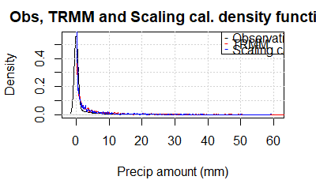

```r
legend("topright", legend = c("Observation","TRMM", "Scaling calibration"), pch ='-', col = c("black", "red", "blue"))
```

```r
qqplot(obs.madrid$Data, trmm.madrid$Data, main = "Obs,TRMM and Scaling calibration QQplot", xlab = "Observed (mm)", ylab = "TRMM/Calibration (mm)", col = "red")

abline(a = 0, b = 1)
```

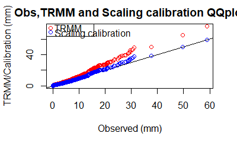

```r
points(sort(obs.madrid$Data), sort(cal.madrid.scaling$Data), col = "blue")

legend("topleft", legend = c("TRMM", "Scaling calibration"), pch = 1, col = c("red", "blue"))
```

```r
plot(density(obs.madrid$Data, na.rm = TRUE),
main = "Obs, TRMM and EQM cal. density function",
xlab = "Precip amount (mm)")
grid()
```

```r
lines(density(trmm.madrid$Data, na.rm = TRUE), col = "red")
lines(density(cal.madrid.eqm$Data, na.rm = TRUE), col = "blue")
```

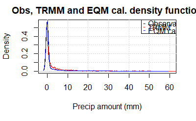

```r
legend("topright", legend = c("Observation","TRMM", "EQM calibration"), pch ='-', col = c("black", "red", "blue"))
```

```r
qqplot(obs.madrid$Data, trmm.madrid$Data, main = "Obs,TRMM and EQM calibration QQplot", xlab = "Observed (mm)", ylab = "TRMM/Calibration (mm)", col = "red")

abline(a = 0, b = 1)
```

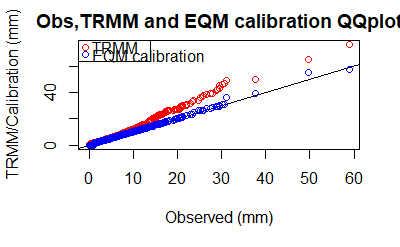

```r
points(sort(obs.madrid$Data), sort(cal.madrid.eqm$Data), col = "blue")

legend("topleft", legend = c("TRMM", "EQM calibration"), pch = 1, col = c("red", "blue"))
```

```r
plot(density(obs.madrid$Data, na.rm = TRUE),
main = "Obs, TRMM and EQM extrapol cal. density function",
xlab = "Precip amount (mm)")
grid()
```

```r
lines(density(trmm.madrid$Data, na.rm = TRUE), col = "red")
lines(density(cal.madrid.eqm.extrapol$Data, na.rm = TRUE), col = "blue")
```

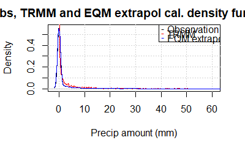

```r
legend("topright", legend = c("Observation","TRMM", "EQM extrapol calibration"), pch ='-', col = c("black", "red", "blue"))
```

```r
qqplot(obs.madrid$Data, trmm.madrid$Data, main = "Obs,TRMM and EQM extrapol calibration QQplot", xlab = "Observed (mm)", ylab = "TRMM/Calibration (mm)", col = "red")

abline(a = 0, b = 1)
```

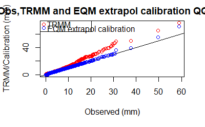

```r
points(sort(obs.madrid$Data), sort(cal.madrid.eqm.extrapol$Data), col = "blue")

legend("topleft", legend = c("TRMM", "EQM extrapol calibration"), pch = 1, col = c("red", "blue"))
```

```r
plot(density(obs.madrid$Data, na.rm = TRUE),
main = "Obs, TRMM and PQM cal. density function",
xlab = "Precip amount (mm)")
grid()
```

```r
lines(density(trmm.madrid$Data, na.rm = TRUE), col = "red")
lines(density(cal.madrid.pqm$Data, na.rm = TRUE), col = "blue")
```

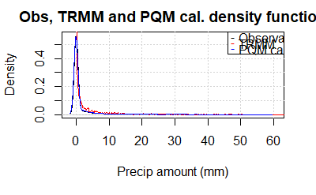

```r
legend("topright", legend = c("Observation","TRMM", "PQM calibration"), pch ='-', col = c("black", "red", "blue"))
```

```r
qqplot(obs.madrid$Data, trmm.madrid$Data, main = "Obs,TRMM and PQM calibration QQplot", xlab = "Observed (mm)", ylab = "TRMM/Calibration (mm)", col = "red")

abline(a = 0, b = 1)
```

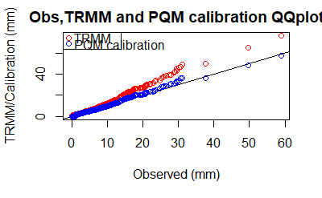

```r
points(sort(obs.madrid$Data), sort(cal.madrid.pqm$Data), col = "blue")

legend("topleft", legend = c("TRMM", "PQM calibration"), pch = 1, col = c("red", "blue"))
```

```r
plot(density(obs.madrid$Data, na.rm = TRUE),
main = "Obs, TRMM and GPQM cal. density function",
xlab = "Precip amount (mm)")
grid()
```

```r
lines(density(trmm.madrid$Data, na.rm = TRUE), col = "red")
lines(density(cal.madrid.gpqm$Data, na.rm = TRUE), col = "blue")
```

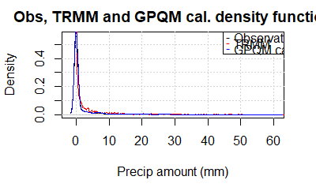

```r
legend("topright", legend = c("Observation","TRMM", "GPQM calibration"), pch ='-', col = c("black", "red", "blue"))
```

```r
qqplot(obs.madrid$Data, trmm.madrid$Data, main = "Obs,TRMM and GPQM calibration QQplot", xlab = "Observed (mm)", ylab = "TRMM/Calibration (mm)", col = "red")

abline(a = 0, b = 1)
```

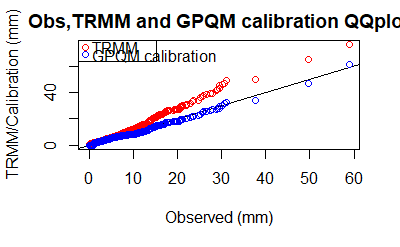

```r
points(sort(obs.madrid$Data), sort(cal.madrid.gpqm$Data), col = "blue")

legend("topleft", legend = c("TRMM", "GPQM calibration"), pch = 1, col = c("red", "blue"))
```

We can note that, in general, EQM is the best approach for the calibration in Madrid-Barajas station. The least differences with the observation data are principally with EQM calibration. In particular in Skewness, R10, R20 and R20p. The difference are really small, and this shows than a calibration with EQM in this case can improve the quality of the data. The best approach in R10p index is made with PQM. Finally, for P98Wet and P98WetAmount indices the best correction is made with GPQM, although the values corrected are quite similar to the obtained with EQM.

Before analyzing another station, let check the density function of Observational, TRMM and TRMM calibrated data. The aim is to check that TRMM calibrated density function approximates well the observational density function. In the other side, we also show that TRMM raw density funciton is a worse approximation.

This steps are repeated in several stations of our selection.

# MÁLAGA

In this cell, some steps are taken:

- Subset observational data for the required station
- Subset TRMM data for the required station
- Observational and TRMM index are computed
- For each calibration method, a dataset calibrated and the index of study are obtained.

```r
obs.malaga <- subsetGrid(obs, station.id = obs$Metadata$station_id[4])
idx <- which.min(abs(trmm$xyCoords$x - obs.malaga$xyCoords$x))
lon <- trmm$xyCoords$x[idx]

idx2 <- which.min(abs(trmm$xyCoords$y - obs.malaga$xyCoords$y))
lat <- trmm$xyCoords$y[idx2]

trmm.malaga <- subsetGrid(trmm, lonLim = lon, latLim = lat)

index.obs.malaga <- valueIndex1D(obs.malaga$Data,index.codes=c("Skewness","R10","R10p","R20","R20p","P98Wet","P98WetAmount"))

index.trmm.malaga <- valueIndex1D(trmm.malaga$Data,index.codes=c("Skewness","R10","R10p","R20","R20p","P98Wet","P98WetAmount"))

index.obs.malaga.rv13max <- MaxReturnValue(obs.malaga)

index.trmm.malaga.rv13max <- MaxReturnValue(trmm.malaga)

cal.malaga.scaling <- biasCorrection(y = obs.malaga, x = trmm.malaga, newdata = trmm.malaga, precipitation = TRUE, cross.val = "loo", method = "scaling", scaling.type = "multiplicative")

cal.malaga.scaling$Dates$start <- as.POSIXct(cal.malaga.scaling$Dates$start,tz = "GMT")
cal.malaga.scaling$Dates$end <- as.POSIXct(cal.malaga.scaling$Dates$end,tz = "GMT")

index.malaga.scaling.rv13max <- MaxReturnValue(cal.malaga.scaling)


index.cal.malaga.scaling <- valueIndex1D(cal.malaga.scaling$Data,index.codes=c("Skewness","R10","R10p","R20","R20p","P98Wet","P98WetAmount"))

cal.malaga.eqm <- biasCorrection(y = obs.malaga, x = trmm.malaga, newdata = trmm.malaga, precipitation = TRUE, cross.val = "loo", method = "eqm")

cal.malaga.eqm$Dates$start <- as.POSIXct(cal.malaga.eqm$Dates$start,tz = "GMT")
cal.malaga.eqm$Dates$end <- as.POSIXct(cal.malaga.eqm$Dates$end,tz = "GMT")

index.cal.malaga.eqm.rv13max <- MaxReturnValue(cal.malaga.eqm)


index.cal.malaga.eqm <- valueIndex1D(cal.malaga.eqm$Data,index.codes=c("Skewness","R10","R10p","R20","R20p","P98Wet","P98WetAmount"))

cal.malaga.eqm.extrapol <- biasCorrection(y = obs.malaga, x = trmm.malaga, newdata = trmm.malaga, precipitation = TRUE, cross.val = "loo", method = "eqm",extrapolation = "constant")

cal.malaga.eqm.extrapol$Dates$start <- as.POSIXct(cal.malaga.eqm.extrapol$Dates$start,tz = "GMT")
cal.malaga.eqm.extrapol$Dates$end <- as.POSIXct(cal.malaga.eqm.extrapol$Dates$end,tz = "GMT")

index.cal.malaga.eqm.extrapol.rv13max <- MaxReturnValue(cal.malaga.eqm.extrapol)


index.cal.malaga.eqm.extrapol <- valueIndex1D(cal.malaga.eqm.extrapol$Data,index.codes=c("Skewness","R10","R10p","R20","R20p","P98Wet","P98WetAmount"))

cal.malaga.pqm <- biasCorrection(y = obs.malaga, x = trmm.malaga, newdata = trmm.malaga, precipitation = TRUE, cross.val = "loo", method = "pqm",  fitdistr.args = list(densfun = "gamma"))

cal.malaga.pqm$Dates$start <- as.POSIXct(cal.malaga.pqm$Dates$start,tz = "GMT")
cal.malaga.pqm$Dates$end <- as.POSIXct(cal.malaga.pqm$Dates$end,tz = "GMT")

index.cal.malaga.pqm.rv13max <- MaxReturnValue(cal.malaga.pqm)

index.cal.malaga.pqm <- valueIndex1D(cal.malaga.pqm$Data,index.codes=c("Skewness","R10","R10p","R20","R20p","P98Wet","P98WetAmount"))

cal.malaga.gpqm <- biasCorrection(y = obs.malaga, x = trmm.malaga, newdata = trmm.malaga, precipitation = TRUE, cross.val = "loo", method = "gpqm", theta = 0.7)

cal.malaga.gpqm$Dates$start <- as.POSIXct(cal.malaga.gpqm$Dates$start,tz = "GMT")
cal.malaga.gpqm$Dates$end <- as.POSIXct(cal.malaga.gpqm$Dates$end,tz = "GMT")

index.cal.malaga.gpqm.rv13max <- MaxReturnValue(cal.malaga.gpqm)

index.cal.malaga.gpqm <- valueIndex1D(cal.malaga.gpqm$Data,index.codes=c("Skewness","R10","R10p","R20","R20p","P98Wet","P98WetAmount"))
```

Showing Málaga station results

```r
index.obs.malaga <- c(index.obs.malaga,index.obs.malaga.rv13max)
index.trmm.malaga <- c(index.trmm.malaga,index.trmm.malaga.rv13max)
index.cal.malaga.scaling <- c(index.cal.malaga.scaling,index.malaga.scaling.rv13max)
index.cal.malaga.eqm <- c(index.cal.malaga.eqm,index.cal.malaga.eqm.rv13max)
index.cal.malaga.eqm.extrapol <- c(index.cal.malaga.eqm.extrapol,index.cal.malaga.eqm.extrapol.rv13max)
index.cal.malaga.pqm <- c(index.cal.malaga.pqm,index.cal.malaga.pqm.rv13max)
index.cal.malaga.gpqm <- c(index.cal.malaga.gpqm,index.cal.malaga.gpqm.rv13max)

results.malaga <- data.frame(index.obs.malaga, index.trmm.malaga, index.cal.malaga.scaling,
                      index.cal.malaga.eqm,index.cal.malaga.eqm.extrapol, index.cal.malaga.pqm, index.cal.malaga.gpqm
                      )

colnames(results.malaga) <- c("Obs","TRMM","Scaling cal.", "EQM cal.", "EQM extrapol cal.","PQM cal.","GPQM cal.")

results.malaga <- format(results.malaga, digits = 3, scientific = 5)

results.malaga
```

[output not shown]

```r
 diff.malaga <- data.frame(abs(index.trmm.malaga-index.obs.malaga),abs(index.cal.malaga.scaling-index.obs.malaga),
                      abs(index.cal.malaga.eqm-index.obs.malaga),abs(index.cal.malaga.eqm.extrapol-index.obs.malaga), abs(index.cal.malaga.pqm-index.obs.malaga), abs(index.cal.malaga.gpqm-index.obs.malaga)
                      )
colnames(diff.malaga) <- c("TRMM","Scaling cal.", "EQM cal.","EQM extrapol cal.", "PQM cal.","GPQM cal.")

diff.malaga <- format(diff.malaga, digits = 3, scientific = 5)

diff.malaga
```

[output not shown]

```r
 diff.malaga.noabs <- data.frame(index.trmm.malaga-index.obs.malaga,index.cal.malaga.scaling-index.obs.malaga,
                      index.cal.malaga.eqm-index.obs.malaga,index.cal.malaga.eqm.extrapol-index.obs.malaga, index.cal.malaga.pqm-index.obs.malaga, index.cal.malaga.gpqm-index.obs.malaga)
colnames(diff.malaga.noabs) <- c("TRMM","Scaling_cal", "EQM_cal","EQM_cal.Extrapol", "PQM_cal","GPQM_cal")



formattable(diff.malaga.noabs, list(
  'TRMM' = formatter("span",
                         style = ~style(font.weight = "bold", color =
                                          ifelse(TRMM > 0,"red",
                                                 ifelse(TRMM == 0,"black",
                                                        ifelse(TRMM <0, "blue",NA))))),
  'Scaling_cal' = formatter("span",
                          style = ~style(font.weight = "bold", color =
                                           ifelse(Scaling_cal > 0,"red",
                                                  ifelse(Scaling_cal == 0,"black",
                                                         ifelse(Scaling_cal <0, "blue",NA))))),

   'EQM_cal' = formatter("span",
                          style = ~style(font.weight = "bold", color =
                                           ifelse(EQM_cal > 0,"red",
                                                  ifelse(EQM_cal == 0,"black",
                                                         ifelse(EQM_cal <0, "blue",NA))))),
   'EQM_cal.Extrapol' = formatter("span",
                         style = ~style(font.weight = "bold", color =
                                           ifelse(EQM_cal.Extrapol > 0,"red",
                                                  ifelse(EQM_cal.Extrapol == 0,"black",
                                                         ifelse(EQM_cal.Extrapol <0, "blue",NA))))),
   'PQM_cal' = formatter("span",
                          style = ~style(font.weight = "bold", color =
                                           ifelse(PQM_cal > 0,"red",
                                                  ifelse(PQM_cal == 0,"black",
                                                         ifelse(PQM_cal <0, "blue",NA))))),
   'GPQM_cal' = formatter("span",
                          style = ~style(font.weight = "bold", color =
                                           ifelse(GPQM_cal > 0,"red",
                                                  ifelse(GPQM_cal == 0,"black",
                                                         ifelse(GPQM_cal <0, "blue",NA)))))
 ))
```

[output not shown]

```r
plot(density(obs.malaga$Data, na.rm = TRUE),
main = "Obs, TRMM and Scaling cal. density function",
xlab = "Precip amount (mm)")
grid()
```

```r
lines(density(trmm.malaga$Data, na.rm = TRUE), col = "red")
lines(density(cal.malaga.scaling$Data, na.rm = TRUE), col = "blue")
```

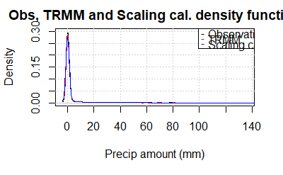

```r
legend("topright", legend = c("Observation","TRMM", "Scaling calibration"), pch ='-', col = c("black", "red", "blue"))
```

```r
qqplot(obs.malaga$Data, trmm.malaga$Data, main = "Obs,TRMM and Scaling calibration QQplot", xlab = "Observed (mm)", ylab = "TRMM/Calibration (mm)", col ="red")

abline(a = 0, b = 1)
```

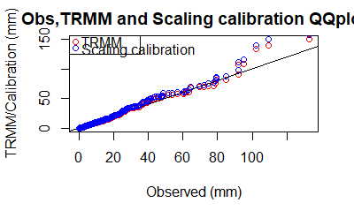

```r
points(sort(obs.malaga$Data), sort(cal.malaga.scaling$Data), col = "blue")

legend("topleft", legend = c("TRMM", "Scaling calibration"), pch = 1, col = c("red", "blue"))
```

```r
plot(density(obs.malaga$Data, na.rm = TRUE),
main = "Obs, TRMM and EQM cal. density function",
xlab = "Precip amount (mm)")
grid()
```

```r
lines(density(trmm.malaga$Data, na.rm = TRUE), col = "red")
lines(density(cal.malaga.eqm$Data, na.rm = TRUE), col = "blue")
```

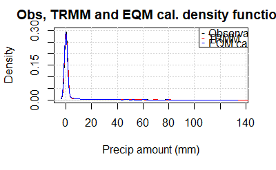

```r
legend("topright", legend = c("Observation","TRMM", "EQM calibration"), pch ='-', col = c("black", "red", "blue"))
```

```r
qqplot(obs.malaga$Data, trmm.malaga$Data, main = "Obs,TRMM and EQM calibration QQplot", xlab = "Observed (mm)", ylab = "TRMM/Calibration (mm)", col = "red")

abline(a = 0, b = 1)
```

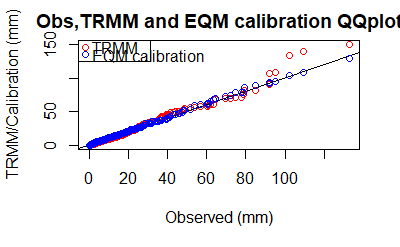

```r
points(sort(obs.malaga$Data), sort(cal.malaga.eqm$Data), col = "blue")

legend("topleft", legend = c("TRMM", "EQM calibration"), pch = 1, col = c("red", "blue"))
```

```r
plot(density(obs.malaga$Data, na.rm = TRUE),
main = "Obs, TRMM and EQM extrapol cal. density function",
xlab = "Precip amount (mm)")
grid()
```

```r
lines(density(trmm.malaga$Data, na.rm = TRUE), col = "red")
lines(density(cal.malaga.eqm.extrapol$Data, na.rm = TRUE), col = "blue")
```

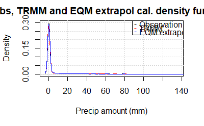

```r
legend("topright", legend = c("Observation","TRMM", "EQM extrapol calibration"), pch ='-', col = c("black", "red", "blue"))
```

```r
qqplot(obs.malaga$Data, trmm.malaga$Data, main = "Obs,TRMM and EQM extrapol calibration QQplot", xlab = "Observed (mm)", ylab = "TRMM/Calibration (mm)", col = "red")

abline(a = 0, b = 1)
```

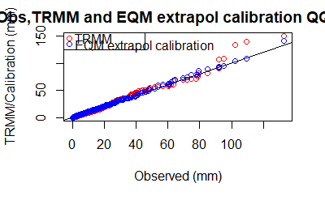

```r
points(sort(obs.malaga$Data), sort(cal.malaga.eqm.extrapol$Data), col = "blue")

legend("topleft", legend = c("TRMM", "EQM extrapol calibration"), pch = 1, col = c("red", "blue"))
```

```r
plot(density(obs.malaga$Data, na.rm = TRUE),
main = "Obs, TRMM and PQM cal. density function",
xlab = "Precip amount (mm)")
grid()
```

```r
lines(density(trmm.malaga$Data, na.rm = TRUE), col = "red")
lines(density(cal.malaga.pqm$Data, na.rm = TRUE), col = "blue")
```

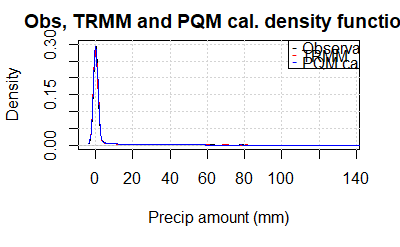

```r
legend("topright", legend = c("Observation","TRMM", "PQM calibration"), pch ='-', col = c("black", "red", "blue"))
```

```r
qqplot(obs.malaga$Data, trmm.malaga$Data, main = "Obs,TRMM and PQM calibration QQplot", xlab = "Observed (mm)", ylab = "TRMM/Calibration (mm)", col = "red")

abline(a = 0, b = 1)
```

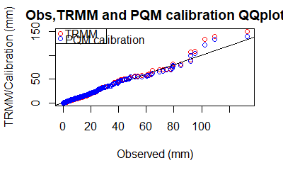

```r
points(sort(obs.malaga$Data), sort(cal.malaga.pqm$Data), col = "blue")

legend("topleft", legend = c("TRMM", "PQM calibration"), pch = 1, col = c("red", "blue"))
```

```r
plot(density(obs.malaga$Data, na.rm = TRUE),
main = "Obs, TRMM and GPQM cal. density function",
xlab = "Precip amount (mm)")
grid()
```

```r
lines(density(trmm.malaga$Data, na.rm = TRUE), col = "red")
lines(density(cal.malaga.gpqm$Data, na.rm = TRUE), col = "blue")
```

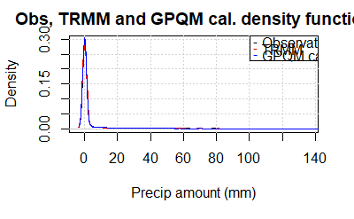

```r
legend("topright", legend = c("Observation","TRMM", "GPQM calibration"), pch ='-', col = c("black", "red", "blue"))
```

```r
qqplot(obs.malaga$Data, trmm.malaga$Data, main = "Obs,TRMM and GPQM calibration QQplot", xlab = "Observed (mm)", ylab = "TRMM/Calibration (mm)", col = "red")

abline(a = 0, b = 1)
```

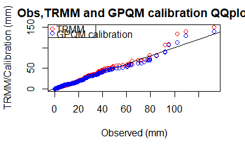

```r
points(sort(obs.malaga$Data), sort(cal.malaga.gpqm$Data), col = "blue")

legend("topleft", legend = c("TRMM", "GPQM calibration"), pch = 1, col = c("red", "blue"))
```

# PALMA DE MALLORCA

Methodology is the same, but the station to study is Palma de Mallorca

```r
obs.mallorca <- subsetGrid(obs, station.id = obs$Metadata$station_id[10])
idx <- which.min(abs(trmm$xyCoords$x - obs.mallorca$xyCoords$x))
lon <- trmm$xyCoords$x[idx]

idx2 <- which.min(abs(trmm$xyCoords$y - obs.mallorca$xyCoords$y))
lat <- trmm$xyCoords$y[idx2]

trmm.mallorca <- subsetGrid(trmm, lonLim = lon, latLim = lat)

index.obs.mallorca <- valueIndex1D(obs.mallorca$Data,index.codes=c("Skewness","R10","R10p","R20","R20p","P98Wet","P98WetAmount"))

index.trmm.mallorca <- valueIndex1D(trmm.mallorca$Data,index.codes=c("Skewness","R10","R10p","R20","R20p","P98Wet","P98WetAmount"))

index.obs.mallorca.rv13max <- MaxReturnValue(obs.mallorca)

index.trmm.mallorca.rv13max <- MaxReturnValue(trmm.mallorca)

cal.mallorca.scaling <- biasCorrection(y = obs.mallorca, x = trmm.mallorca, newdata = trmm.mallorca, precipitation = TRUE, cross.val = "loo", method = "scaling", scaling.type = "multiplicative")

cal.mallorca.scaling$Dates$start <- as.POSIXct(cal.mallorca.scaling$Dates$start,tz = "GMT")
cal.mallorca.scaling$Dates$end <- as.POSIXct(cal.mallorca.scaling$Dates$end,tz = "GMT")

index.cal.mallorca.scaling.rv13max <- MaxReturnValue(cal.mallorca.scaling)

index.cal.mallorca.scaling <- valueIndex1D(cal.mallorca.scaling$Data,index.codes=c("Skewness","R10","R10p","R20","R20p","P98Wet","P98WetAmount"))

cal.mallorca.eqm <- biasCorrection(y = obs.mallorca, x = trmm.mallorca, newdata = trmm.mallorca, precipitation = TRUE, cross.val = "loo", method = "eqm")

cal.mallorca.eqm$Dates$start <- as.POSIXct(cal.mallorca.eqm$Dates$start,tz = "GMT")
cal.mallorca.eqm$Dates$end <- as.POSIXct(cal.mallorca.eqm$Dates$end,tz = "GMT")

index.cal.mallorca.eqm.rv13max <- MaxReturnValue(cal.mallorca.eqm)


index.cal.mallorca.eqm <- valueIndex1D(cal.mallorca.eqm$Data,index.codes=c("Skewness","R10","R10p","R20","R20p","P98Wet","P98WetAmount"))

cal.mallorca.eqm.extrapol <- biasCorrection(y = obs.mallorca, x = trmm.mallorca, newdata = trmm.mallorca, precipitation = TRUE, cross.val = "loo", method = "eqm", extrapolation = "constant")

cal.mallorca.eqm.extrapol$Dates$start <- as.POSIXct(cal.mallorca.eqm.extrapol$Dates$start,tz = "GMT")
cal.mallorca.eqm.extrapol$Dates$end <- as.POSIXct(cal.mallorca.eqm.extrapol$Dates$end,tz = "GMT")

index.cal.mallorca.eqm.extrapol.rv13max <- MaxReturnValue(cal.mallorca.eqm.extrapol)


index.cal.mallorca.eqm.extrapol <- valueIndex1D(cal.mallorca.eqm.extrapol$Data,index.codes=c("Skewness","R10","R10p","R20","R20p","P98Wet","P98WetAmount"))

cal.mallorca.pqm <- biasCorrection(y = obs.mallorca, x = trmm.mallorca, newdata = trmm.mallorca, precipitation = TRUE, cross.val = "loo", method = "pqm",  fitdistr.args = list(densfun = "gamma"))

cal.mallorca.pqm$Dates$start <- as.POSIXct(cal.mallorca.pqm$Dates$start,tz = "GMT")
cal.mallorca.pqm$Dates$end <- as.POSIXct(cal.mallorca.pqm$Dates$end,tz = "GMT")

index.cal.mallorca.pqm.rv13max <- MaxReturnValue(cal.mallorca.pqm)

index.cal.mallorca.pqm <- valueIndex1D(cal.mallorca.pqm$Data,index.codes=c("Skewness","R10","R10p","R20","R20p","P98Wet","P98WetAmount"))

cal.mallorca.gpqm <- biasCorrection(y = obs.mallorca, x = trmm.mallorca, newdata = trmm.mallorca, precipitation = TRUE, cross.val = "loo", method = "gpqm", theta = 0.7)
```

[output not shown]

```r
cal.mallorca.gpqm$Dates$start <- as.POSIXct(cal.mallorca.gpqm$Dates$start,tz = "GMT")
cal.mallorca.gpqm$Dates$end <- as.POSIXct(cal.mallorca.gpqm$Dates$end,tz = "GMT")

index.cal.mallorca.gpqm.rv13max <- MaxReturnValue(cal.mallorca.gpqm)

index.cal.mallorca.gpqm <- valueIndex1D(cal.mallorca.gpqm$Data,index.codes=c("Skewness","R10","R10p","R20","R20p","P98Wet","P98WetAmount"))
```

```r
index.obs.mallorca <- c(index.obs.mallorca,index.obs.mallorca.rv13max)
index.trmm.mallorca <- c(index.trmm.mallorca,index.trmm.mallorca.rv13max)
index.cal.mallorca.scaling <- c(index.cal.mallorca.scaling,index.cal.mallorca.scaling.rv13max)
index.cal.mallorca.eqm <- c(index.cal.mallorca.eqm,index.cal.mallorca.eqm.rv13max)
index.cal.mallorca.eqm.extrapol <- c(index.cal.mallorca.eqm.extrapol,index.cal.mallorca.eqm.extrapol.rv13max)
index.cal.mallorca.pqm <- c(index.cal.mallorca.pqm,index.cal.mallorca.pqm.rv13max)
index.cal.mallorca.gpqm <- c(index.cal.mallorca.gpqm,index.cal.mallorca.gpqm.rv13max)

results.mallorca <- data.frame(index.obs.mallorca, index.trmm.mallorca,index.cal.mallorca.scaling,
                      index.cal.mallorca.eqm, index.cal.mallorca.eqm.extrapol ,index.cal.mallorca.pqm, index.cal.mallorca.gpqm
                      )
colnames(results.mallorca) <- c("Obs","TRMM","Scaling cal.", "EQM cal.","EQM extrapol cal", "PQM cal.","GPQM cal.")

results.mallorca <- format(results.mallorca, digits = 3, scientific = 5)

results.mallorca
```

[output not shown]

```r
 diff.mallorca <- data.frame(abs(index.trmm.mallorca-index.obs.mallorca),abs(index.cal.mallorca.scaling-index.obs.mallorca),
                      abs(index.cal.mallorca.eqm-index.obs.mallorca),abs(index.cal.mallorca.eqm.extrapol-index.obs.mallorca), abs(index.cal.mallorca.pqm-index.obs.mallorca), abs(index.cal.mallorca.gpqm-index.obs.mallorca)
                      )
colnames(diff.mallorca) <- c("TRMM","Scaling cal.", "EQM cal.", "EQM extrapol cal.", "PQM cal.","GPQM cal.")

diff.mallorca <- format(diff.mallorca, digits = 3, scientific = 5)


diff.mallorca
```

[output not shown]

```r
 diff.mallorca.noabs <- data.frame(index.trmm.mallorca-index.obs.mallorca,index.cal.mallorca.scaling-index.obs.mallorca,
                      index.cal.mallorca.eqm-index.obs.mallorca, index.cal.mallorca.eqm.extrapol-index.obs.mallorca, index.cal.mallorca.pqm-index.obs.mallorca, index.cal.mallorca.gpqm-index.obs.mallorca)
colnames(diff.mallorca.noabs) <- c("TRMM","Scaling_cal", "EQM_cal","EQM_cal.Extrapol", "PQM_cal","GPQM_cal")



formattable(diff.mallorca.noabs, list(
  'TRMM' = formatter("span",
                         style = ~style(font.weight = "bold", color =
                                          ifelse(TRMM > 0,"red",
                                                 ifelse(TRMM == 0,"black",
                                                        ifelse(TRMM <0, "blue",NA))))),
  'Scaling_cal' = formatter("span",
                          style = ~style(font.weight = "bold", color =
                                           ifelse(Scaling_cal > 0,"red",
                                                  ifelse(Scaling_cal == 0,"black",
                                                         ifelse(Scaling_cal <0, "blue",NA))))),

   'EQM_cal' = formatter("span",
                          style = ~style(font.weight = "bold", color =
                                           ifelse(EQM_cal > 0,"red",
                                                  ifelse(EQM_cal == 0,"black",
                                                         ifelse(EQM_cal <0, "blue",NA))))),
   'EQM_cal.Extrapol' = formatter("span",
                         style = ~style(font.weight = "bold", color =
                                           ifelse(EQM_cal.Extrapol > 0,"red",
                                                  ifelse(EQM_cal.Extrapol == 0,"black",
                                                         ifelse(EQM_cal.Extrapol <0, "blue",NA))))),
   'PQM_cal' = formatter("span",
                          style = ~style(font.weight = "bold", color =
                                           ifelse(PQM_cal > 0,"red",
                                                  ifelse(PQM_cal == 0,"black",
                                                         ifelse(PQM_cal <0, "blue",NA))))),
   'GPQM_cal' = formatter("span",
                          style = ~style(font.weight = "bold", color =
                                           ifelse(GPQM_cal > 0,"red",
                                                  ifelse(GPQM_cal == 0,"black",
                                                         ifelse(GPQM_cal <0, "blue",NA)))))
 ))
```

[output not shown]